# Assignment 1: Image denoising and classification

Nombre 1, Nombre 2

# 0. Introduction

The aim of this assignment is to study how noise affects image data and classification performance, and to investigate whether Principal Component Analysis (PCA) can be used to obtain lower dimensional representations and reconstruct less noisy images. In this assignment, we are working with the MNIST dataset, which consists of grayscale images of handwritten digits (0–9), each of size 28 × 28 pixels. We are going to generate noisy versions of the images using the multivariate normal distribution, apply PCA, and compare the performance of different classification methods.

As there will be several processes which contain some randomness or stochasticity, in order to guarantee the results reproducibility, it is necessary to set a seed. In our case, it will be 42.

```r
seed <- 42
```

# Part 1. Data exploration and preparation

## 1.1

First, we are going to load the dataset and analyze its main properties.

```r
load("MNIST.RData")
```

The dataset consists of two elements. x_MNIST represents the images (one row per image), while y_MNIST contains the number each image corresponds to. Along the project we are going to print several times some of the images, so it is important to get a function which takes the matrix associated and displays the resulting image.

```r
show_digit <- function(v, title = "") {
  img <- matrix(v, nrow = 28, ncol = 28, byrow = TRUE) # we convert a vector into a 28x28 matrix
  image(t(img[28:1, ]), # we plot the image rotated in order to see the number properly
        col = gray.colors(256, start = 1, end = 0), # colors parameters
        axes = FALSE, main = title)
}
```

The next step is to describe the main characteristics of the dataset.

```r
dim(x_MNIST) # dimension of matrix x_MNIST
```

```
## [1] 60000   784
```

```r
length(y_MNIST) # length of vector y_MNIST
```

```
## [1] 60000
```

```r
table(y_MNIST) # Frequency table of numbers
```

```
## y_MNIST
##    0    1    2    3    4    5    6    7    8    9
## 5923 6742 5958 6131 5842 5421 5918 6265 5851 5949
```

```r
range(x_MNIST) # Range of pixel values
```

```
## [1]   0 255
```

```r
sum(is.na(x_MNIST))
```

```
## [1] 0
```

```r
sum(is.na(y_MNIST))
```

```
## [1] 0
```

```r
# We check if there is some missing value
```

We see, as expected, that we have 60000 images, each one of 784 pixels (28 x 28), each one corresponding to a written number. Frequency table of y_MNIST tells us the distribution of those numbers (it looks like quite uniform), while the range of pixels goes from 0 to 255. We also see there are no missing values.

```r
mean(x_MNIST == 0)
```

```
## [1] 0.8087977
```

We have obtained that approximately 80 % of pixels have value 0, which means the distribution is considerably concentrated at 0 (the white background). In the future, this will be important when generating noisy version of images.

Now we study the variability of pixels across images. Each pixel corresponds to a column of X_MNIST, so this quantity is measured with the vector standard deviation.

```r
pixel_sd <- apply(x_MNIST, 2, sd)
sum(pixel_sd == 0)
```

```
## [1] 67
```

We obtain 67 pixels whose standard deviation is 0. This means they have the same value across all images or, equivalently, they do not give any information. This will have several implications while doing dimensionality reduction with PCA.

Before going with train-test split, we are going to scale x_MNIST. Having values in $[0,1]$ instead of $[0,255]$ will allow us to have a better interpretation of the results without losing information.

```r
x_MNIST <- x_MNIST / 255
```

Now, we proceed with train-test split. We select 70 % train, 15% validation and 15% test.

```r
set.seed(seed)

n <- nrow(x_MNIST)
idx <- sample(1:n) # reordering in order to split randomly

n_train <- round(0.70 * n)
n_val <- round(0.15 * n)

idx_train <- idx[1:n_train]
idx_val <- idx[(n_train + 1):(n_train + n_val)]
idx_test <- idx[(n_train + n_val + 1):n]

X_train <- x_MNIST[idx_train, ]
y_train <- y_MNIST[idx_train]
X_val <- x_MNIST[idx_val, ]
y_val <- y_MNIST[idx_val]
X_test <- x_MNIST[idx_test, ]
y_test <- y_MNIST[idx_test]

c(train = nrow(X_train), validation = nrow(X_val), test = nrow(X_test))
```

```
##      train validation       test
##      42000       9000       9000
```

Traditionally, it is split 70% train and 30 % test. We have considerably great amount of images (60000), so 42000 in train allows PCA and classification models to get a good global idea about the data. From now on, we are going to work with train dataset.

## 1.2)

Now we are going to plot some example images, in particular 3 per digit, using function defined in the initial part.

```r
set.seed(seed)
par(mfrow = c(5,6), mar = c(0.1,0.1,0.1,0.1))

for (d in 0:9) {
  id <- sample(which(y_train == d), 3)
  for (i in id) {
    show_digit(X_train[i,])
  }
}
```

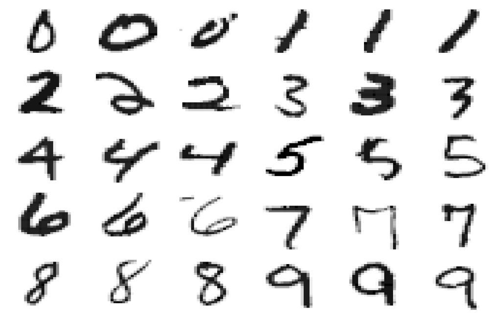

```r
par(mfrow =c(1,1), mar = c(5,4,4,2) + 0.1)
```

Matrix representation models the image as a 28 x 28 matrix. On the other hand, vector representation just takes all the pixels and puts them in a vector living in $\mathbb{R}^{28^2} = \mathbb{R}^{784}$ by placing the rows of the matrix one after another. Both are equivalent, since they contain exactly the same information. The only difference is that the vector representation does not explicitly take into account the spatial structure of the image (which pixels are neighbours of each other): two horizontally adjacent pixels are consecutive elements of the vector, but two vertically adjacent pixels are 28 positions apart. As a consequence, methods such as PCA treat the 784 pixels as ordinary variables, without using the fact that nearby pixels tend to have similar values.

Talking about within-class variety, for each number, we compute the standard deviation for each pixel of every image in the class, and later the average of all those deviations

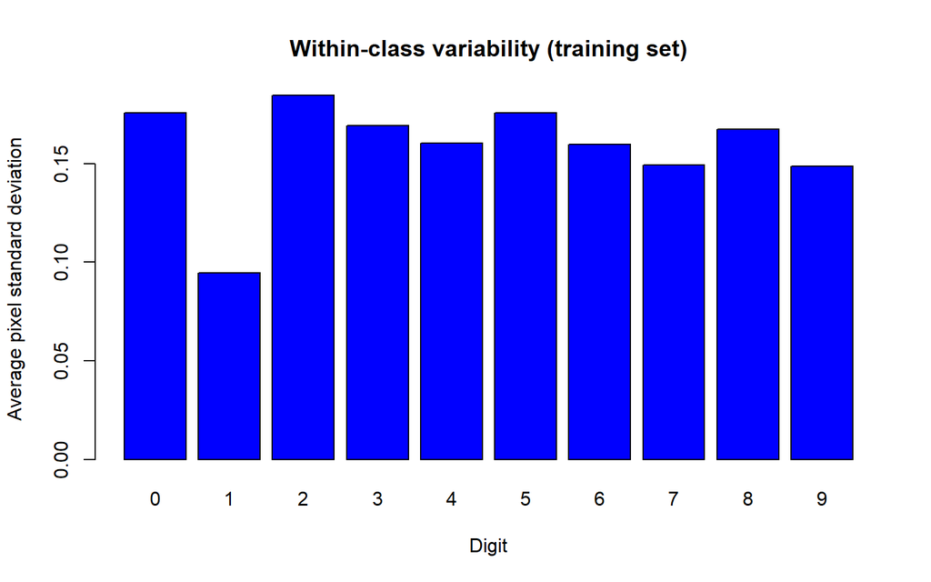

```r
sd_within <- rep(0,10)

for (d in 0:9) {
  sd_within[d+1] <- mean(apply (X_train[y_train == d,], 2, sd))
}

names(sd_within) <- 0:9
barplot(sd_within, col = "blue", main = "Within-class variability (training set)", xlab = "Digit", ylab = "Average pixel standard deviation")
```

We can appreciate that the order of standard deviation is $10^{-1}$ for all the classes. Additionally, the majority of them are around $0.15$ except of number 1, which is the least variable class with a standard deviation around $0.10$.

To study the similarity between classes, we compute the Euclidean distance between the mean images of the different digits, that is, between their sample mean vectors $\underline{\bar{x}}_0, \ldots, \underline{\bar{x}}_9 \in \mathbb{R}^{784}$. We use the Euclidean distance because all pixels are measured on the same scale, and the Mahalanobis distance cannot be computed since the sample covariance matrix is singular (some pixels have zero variance).

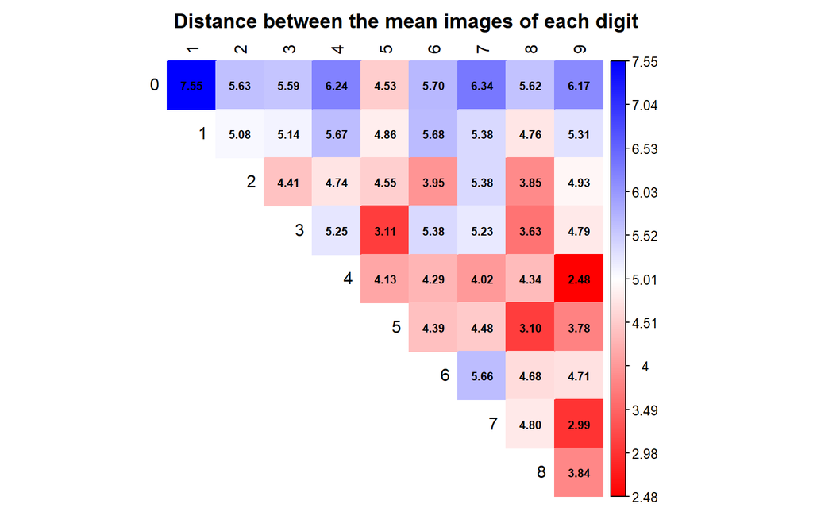

```r
class_means <- matrix(0, nrow = 10, ncol = 784)


for (d in 0:9) {
  class_means[d + 1, ] <- colMeans(X_train[y_train == d, ])
}

rownames(class_means) <- 0:9

D <- as.matrix(dist(class_means)) # distance between rows (average image of each class)

library(corrplot)
corrplot(D,
         is.corr = FALSE,          # it is not a correlation matrix
         method = "color",
         type = "upper",
         diag = FALSE,             # without diagonal
         addCoef.col = "black",    # value in each cell
         number.cex = 0.7,
         tl.col = "black",
         col = colorRampPalette(c("red", "white", "blue"))(200),
         title = "Distance between the mean images of each digit",
         mar = c(0, 0, 2, 0))
```

The distances should be interpreted in relative terms, since their absolute value depends on the pixel scale and on the number of pixels. The most similar pair of digits is 4 and 9 (distance 2.48), which differ mainly in whether the top of the digit is closed. Other close pairs are 7 and 9 (2.99) and the digits 3, 5 and 8 (distances between 3.10 and 3.63). On the other hand, the most different pair is 0 and 1 (7.55): a ring and a vertical stroke have almost no ink pixels in common. Digits whose mean images are close are expected to be harder to distinguish, so we expect these would be the most difficult cases for our classification models.

## 1.3)

Now we are going to study the distribution of observations among the different classes. As we saw in 1.1), frequency table showed the classes were pretty balanced. This is also supported with the relative frequencies:

```r
prop.table(table(y_MNIST))
```

```
## y_MNIST
##          0          1          2          3          4          5          6
## 0.09871667 0.11236667 0.09930000 0.10218333 0.09736667 0.09035000 0.09863333
##          7          8          9
## 0.10441667 0.09751667 0.09915000
```

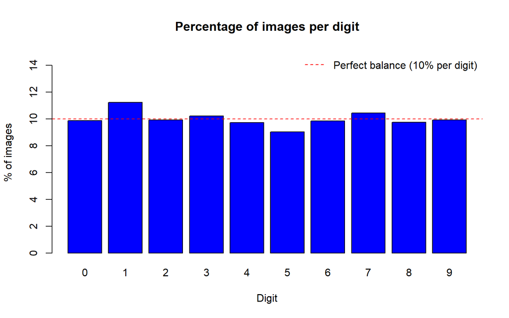

```r
percentage <- round(prop.table(table(y_MNIST))*100, 2)
barplot(percentage, col = "blue", ylim = c(0, 15),
        main = "Percentage of images per digit",
        xlab = "Digit", ylab = "% of images")
abline(h = 10, lty = 2, col = "red")   # 10 % line (perfectly balanced)
legend("topright", legend = "Perfect balance (10% per digit)",
       lty = 2, col = "red", bty = "n")
```

The barplot shows clearly that there is no significant imbalance, as all the classes percentage are considerably close to the perfect balance line. This fact has several implications, such as making accuracy a reliable metric.

However, we have checked balancing in the total dataset. In order to guarantee that the train, validation and test sets are representative of the whole dataset., each split must have a similar behaviour, which means they need to be also balanced. We check it now:

```r
round(100 * rbind(train      = prop.table(table(y_train)),
                  validation = prop.table(table(y_val)),
                  test       = prop.table(table(y_test))), 2)
```

```
##                0     1     2     3     4    5    6     7     8     9
## train       9.88 11.22  9.91 10.29  9.62 9.18 9.90 10.54  9.62  9.86
## validation  9.61 11.04  9.84  9.97 10.09 9.06 9.69 10.38 10.17 10.16
## test       10.11 11.51 10.12 10.13  9.94 8.33 9.88 10.07  9.97  9.93
```

We obtain similar results, so our division is appropriate for the following tasks.

# Part 2. Noise generation using the multivariate normal distribution.

## 2.1

In this section we will add random noise to our training dataset. We will generate three noise levels using a multivariate normal distribution. Given the vector $\mathbf{x}_i\in\mathbb{R}^784$ corresponding to image $i$, the noisy version will be:
$$\mathbf{x}_i^* =
\mathbf{x}_i + \epsilon_i,$$
where $\epsilon_i$ is obtained from the distribuition $\mathcal{N}_784(\mathbf{0},\sigma^2\mathbf{I}_784)$.

As the noise has mean 0, adding the noise to the images will not make them any brighter or darker, on average

The covariance matrix of the noise distribution, $\Sigma = \sigma^2\mathbf{I}_784$, is a scalar matrix. This implies the noise components for each pixel are uncorrelated and identically distributed. Furthermore, as the noise generated follows a multivariate normal distribuition, the components corresponding to each pixel will be independent from each other.

The marginal distribution of each noise component is therefore $\mathcal{N}(0,\sigma^2)$.

To model three different noise levels, we will generate noisy versions using three different values of $\sigma$. To decide which values of $\sigma$ are apropiate, we will consider the Signal to Noise ratio, which is commonly defined as:
$$SNR=\frac{\bar{\mathbf{X}^2}}{\sigma^2},$$
where $\bar{\mathbf{X}^2}$ represents the mean value of the signal squared, in this case, of the pixels.

As the images are mostly white background, the mean square value will be dragged towards 0, which will result in lower noise than we want. To avoid this, we will calculate the mean square of the pixels which are not completely white.

A signal to noise ratio greater than one corresponds to low noise, or a clean signal. Conversely, a signal to noise ratio lower than 1 corresponds to a noisy image. We will aim to have an $SNR$ of 2 for the low noise signal, 1 for the medium noise signal and 0.5 for the high noise signal.

```r
musq <- mean(X_train[X_train!=0]^2) # Calculate the square mean of the non zero pixels
sigmaLow <- sqrt(musq/2)
sigmaLow
```

```
## [1] 0.5411652
```

```r
sigmaMedium <- sqrt(musq)
sigmaMedium
```

```
## [1] 0.7653232
```

```r
sigmaHigh <- sqrt(musq/0.5)
sigmaHigh
```

```
## [1] 1.08233
```

We obtain the following values for $\sigma$. Low noise, $\sigma = 0.5411652$, medium noise, $\sigma = 0.7653232$, and high noise, $\sigma = 1.08233$.

## 2.2

We will now generate the noisy datasets. To ensure repoducibility we set the seed once before generating the noise. This ensure the noise generated is the same on every execution while being different for every pixel in every image.

As the generated noise could make the pixel value fall out of the $[0,1]$ interval, we will clip the values after the noise has been added. Therefore if a certain pixel will end up with a value lower than 0, we set it to 0, and it its value will be greater than 1, we set it to 1.

```r
set.seed(seed) # Seed for reproducibility

m = ncol(X_train) # Number of pixels

# Initialize copies of the dataset
X_low <- X_train
X_medium <- X_train
X_high <- X_train

# Loop over the images
for (i in 1:n_train){
  # Noise generation
  epsLow <- rnorm(m, mean = 0, sd = sigmaLow)
  epsMedium <- rnorm(m, mean = 0, sd = sigmaMedium)
  epsHigh <- rnorm(m, mean = 0, sd = sigmaHigh)
  # Adding noise to the images
  X_low[i,] = X_low[i,] + epsLow
  X_medium[i,] = X_medium[i,] + epsMedium
  X_high[i,] = X_high[i,] + epsHigh
}
# Clipping values to [0,1]
X_low <- pmin(pmax(X_low,0),1)
X_medium <- pmin(pmax(X_medium,0),1)
X_high <- pmin(pmax(X_high,0),1)
```

# 2.3

To showcase the noisy images we have generated, we will show the same set of 30 images we displayed for the clean dataset with each noise level added.

Clean images.

```r
set.seed(seed)
par(mfrow = c(5, 6), mar = c(0.1, 0.1, 0.1, 0.1))

for (d in 0:9) {
  id <- sample(which(y_train == d), 3)
  for (i in id) {
    show_digit(X_train[i, ])
  }
}
```

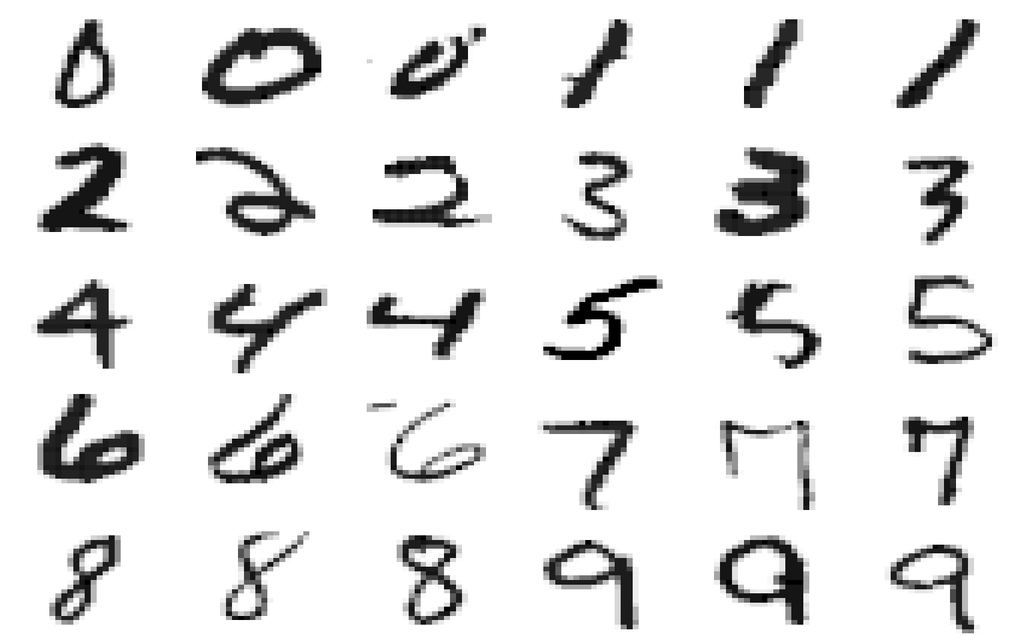

Low noise images, $\sigma = 0.5411652$.

```r
set.seed(seed)
par(mfrow = c(5, 6), mar = c(0.1, 0.1, 0.1, 0.1))

for (d in 0:9) {
  id <- sample(which(y_train == d), 3)
  for (i in id) {
    show_digit(X_low[i, ])
  }
}
```

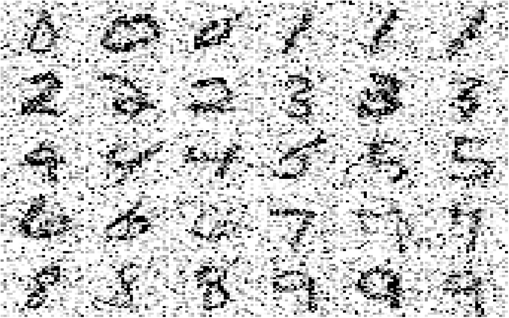

Medium noise images, $\sigma = 0.7653232$.

```r
set.seed(seed)
par(mfrow = c(5, 6), mar = c(0.1, 0.1, 0.1, 0.1))

for (d in 0:9) {
  id <- sample(which(y_train == d), 3)
  for (i in id) {
    show_digit(X_medium[i, ])
  }
}
```

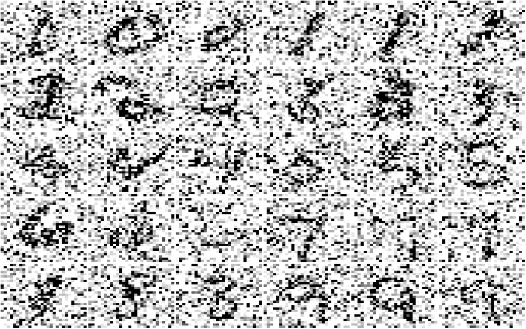

High noise images, $\sigma = 1.08233$.

```r
set.seed(seed)
par(mfrow = c(5, 6), mar = c(0.1, 0.1, 0.1, 0.1))

for (d in 0:9) {
  id <- sample(which(y_train == d), 3)
  for (i in id) {
    show_digit(X_high[i, ])
  }
}
```

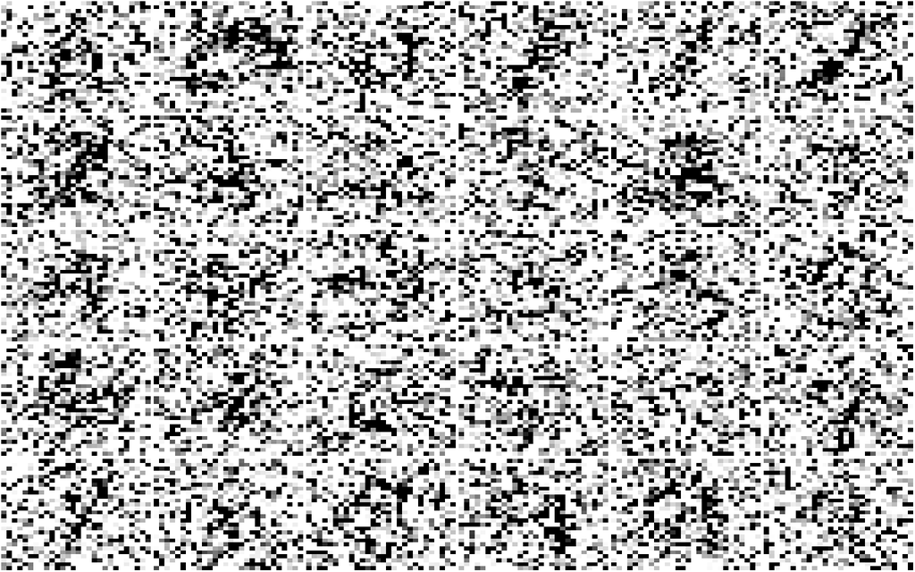

In the images we can clearly see that increasing $\sigma$ makes the digits more and more unrecognisable.